# Assignment 4: Logistic Regression

This material, no matter whether in printed or electronic form, may be used for personal and non-commercial educational use only. Any reproduction of this material, no matter whether as a whole or in parts, no matter whether in printed or in electronic form, requires explicit prior acceptance of the authors.

## Task 1: Proof details for logistic regression

The coefficients $\mathbf{w}$ of the Logistic Regression problem are usually estimated using the maximum likelihood method. Assuming that all the observations in the sample are independently Bernoulli distributed, this leads to the optimization problem

\begin{align*} \min_{\mathbf{w}} L &= \min_{\mathbf{w}} \bigl( -\sum_i [ y_i \log \sigma(\mathbf{w}^T\mathbf{x}_i) + (1-y_i) \log (1-\sigma(\mathbf{w}^T \mathbf{x}_i))] \bigr), \\ \text{with} \quad \sigma(x) &= \frac{1}{1+\mathrm{e}^{-x}}, \end{align*}

where $L = -\ln \mathcal{L}$ is the negative log-likelihood. Since there is no closed-form solution for $\mathbf{w}$, an iterative method $-$ such as gradient descent $-$ must be applied in order to find $\mathbf{w}$.

### Task:

Calculate the gradient $\frac{\partial L}{\partial \mathbf{w}}$, which is needed to apply gradient descent. Hint: $\frac{\partial \sigma(x)}{\partial x} = \sigma(x)\ (1 - \sigma(x))$.

### Calculation (25 points):

To calculate gradient of the negative log-liklihood \begin{align} \frac{\partial L}{\partial\mathbf{w}} & =\frac{\partial L}{\partial\sigma}\frac{\partial\sigma}{\partial\mathbf{w}}=-\sum_{i}[\frac{\partial}{\partial\sigma(\mathbf{w}^{T}\mathbf{x}_{i})}[y_{i}\log\sigma(\mathbf{w}^{T}\mathbf{x}_{i})+(1-y_{i})\log(1-\sigma(\mathbf{w}^{T}\mathbf{x}_{i}))]\frac{\partial\sigma(\mathbf{w}^{T}\mathbf{x}_{i})}{\partial\mathbf{w}}]=\\ & =-\sum_{i}[(y_{i}\frac{1}{\sigma(\mathbf{w}^{T}\mathbf{x}_{i})}-(1-y_{i})\frac{1}{1-\sigma(\mathbf{w}^{T}\mathbf{x}_{i})})\frac{\partial\sigma(\mathbf{w}^{T}\mathbf{x}_{i})}{\partial\mathbf{w}}]\\ & =-\sum_{i}[\frac{(y_{i}-\sigma(\mathbf{w}^{T}\mathbf{x}_{i}))}{\sigma(\mathbf{w}^{T}\mathbf{x}_{i})(1-\sigma(\mathbf{w}^{T}\mathbf{x}_{i}))}\frac{\partial\sigma(\mathbf{w}^{T}\mathbf{x}_{i})}{\partial\mathbf{w}}] \end{align}

by considering the hint, \begin{align} \frac{\partial\sigma(\mathbf{w}^{T}\mathbf{x}_{i})}{\partial\mathbf{w}}=\sigma(\mathbf{w}^{T}\mathbf{x}_{i})(1-\sigma(\mathbf{w}^{T}\mathbf{x}_{i}))\mathbf{x}_{i} \end{align}

Therefore, \begin{align} \frac{\partial L}{\partial\mathbf{w}}=-\sum_{i}[\frac{(y_{i}-\sigma(\mathbf{w}^{T}\mathbf{x}_{i}))}{\sigma(\mathbf{w}^{T}\mathbf{x}_{i})(1-\sigma(\mathbf{w}^{T}\mathbf{x}_{i}))}]\sigma(\mathbf{w}^{T}\mathbf{x}_{i})(1-\sigma(\mathbf{w}^{T}\mathbf{x}_{i}))\mathbf{x}_{i}=-\sum_{i}[(y_{i}-\sigma(\mathbf{w}^{T}\mathbf{x}_{i}))\mathbf{x}_{i}] \end{align}

## Task 2: Implementation of Logistic Regression

The goal of this exercise is to implement logistic regression from scratch using numpy.

### Task:

- Implement the formula for the gradient computed in the previous task. In particular you should implement a function `logistic_gradient(w, x, y)` that takes a parameter vector $\mathbf{w}$, a data matrix $\mathbf{X}$ and a label vector $\mathbf{y}$ and returns the gradient $\frac{\partial L}{\partial \mathbf{w}}$.
- Do the same for a function `cost(w, x, y)`, which should implement the cross-entropy error from the lecture.
- Test this function for the gradient by implementing Gradient Checking. To do this, implement a function `numerical_gradient(w, x, y)` that takes the same parameters as `logistic_gradient`, but calculates the gradient numerically via the central difference quotient, using $\epsilon = 10^{-4}$ as suggested in the slides.
- Generate a random data matrix consisting of 5 data points with 10 features drawn from a standard normal distribution as well as corresponding random binary labels and a random weight vector, whose entries again stem from the standard normal distribution. Use them as input of both functions and compare the outputs. Hint: to generate the distributions use `np.random.normal` and `np.random.randint`.

### Code (20 points):

```python
import numpy as np
from sklearn.metrics import roc_curve, auc
import matplotlib
import matplotlib.pyplot as plt
```

```python
# Complete the functions with your code


def logistic_gradient(w, x, y):
    ######################################
    # Begin your code
    sigmoid = lambda z:1/(1 + np.exp(-z))

    y = y.reshape(-1,1)
    z = np.dot(x, w)
    g = sigmoid(z)
    gradient = np.dot(x.T, (g- y))
    return gradient
    # End your code
    ######################################

def cost(w, x, y):
    ######################################
    # Begin your code
    sigmoid = lambda z:1/(1 + np.exp(-z))

    y = y.reshape(-1,1)
    z = np.dot(x, w)
    g = sigmoid(z)
    cross_ent_loss = - np.sum(y * np.log(g) + (1 - y) * np.log(1 - g))
    return cross_ent_loss
    # End your code
    ######################################

def numerical_gradient(w, x, y):
    ######################################
    # Begin your code
    eps = 1e-4
    num_gradient = np.zeros(w.shape)
    for ii in range(w.size):
        e = np.zeros(w.shape)
        e[ii]=eps
        num_gradient[ii] =(cost(w+e, x, y)-cost(w-e, x, y))/(2*eps)
    return num_gradient
    # End your code
    ######################################
```

```python
# Generate random data matrix and compare outputs

#################################################
# Begin your code

x = np.random.normal(size=(5, 10))
y = np.random.randint(2, size=5)
w = np.random.normal(size=(10, 1))
log_gradient = logistic_gradient(w, x, y)
print('logistic_gradient =',log_gradient.T)

num_gradient = numerical_gradient(w, x, y)
print('numerical_gradient =',num_gradient.T)

outputs_mse = np.mean((log_gradient-num_gradient)**2)
print('output MSE =', outputs_mse )


# End your code
#################################################
```

```
logistic_gradient = [[-1.48309451 -2.67846254  3.69266851 -1.33710093  3.93521469 -0.76259068
  -2.87851101  1.29289834  1.13153586  2.18301755]]
numerical_gradient = [[-1.48309451 -2.67846254  3.69266851 -1.33710093  3.93521469 -0.76259068
  -2.87851101  1.29289834  1.13153586  2.18301755]]
output MSE = 7.517997067399465e-19
```

Next we intend to apply logistic regression on a real data set.

### Task:

- Implement a function `fitLogRegModel(x_train, y_train, eta=1e-4, max_iter=100000)` that uses Logistic Regression with Gradient Descent to compute classifiers on the training set. Use randomly initialized weights, drawn from a uniform distribution between $-1$ and $1$, a learning rate $\eta$ of $10^{-4}$ and a maximum number of iterations of $100 000$. Furthermore the algorithm should stop if the difference between the original loss and the current loss is less than $\eta$. Also print the losses after $1000$ step intevals.
- Furthermore, implement a function `predictLogReg(w, x_pred)` that returns the prediction for the given parameter vector $\mathbf{w}$ and feature vector $\mathbf{x}_{\textrm{pred}}$.

Hint: for intialization use `np.random.uniform`.

### Code (20 points)

```python
# Complete the functions with your code

def fitLogRegModel(x_train, y_train, eta=1e-4, max_iter=100000):
    ######################################
    # Begin your code
    w = np.random.uniform(-1,1,size=(x_train.shape[1], 1))
    # Use of break statement inside the loop
    loss=[1]
    for cnt in range(max_iter):
        w = w - eta*logistic_gradient(w, x_train, y_train)
        loss.append(cost(w, x_train, y_train))
        if cnt % 1000 == 0:
            print( 'iter =', cnt, 'loss =', loss[-1])
        if np.abs(loss[-1]-loss[-2])<eta:
            break

    print("Final loss = ",loss[-1], ' iterations =  ',cnt)
    return w
    # End your code
    ######################################

def predictLogReg(w, x_pred):
    ######################################
    # Begin your code
    sigmoid = lambda z:1/(1 + np.exp(-z))

    z = np.dot(x_pred, w)
    y_pred = np.squeeze(sigmoid(z)) # np.rint()
    return y_pred
    # End your code
    ######################################
```

Next we consider `DataSetLR.csv` and split the data set into training set and test set ($50\,\%$ each). We also transformed the labels from $+1$, $-1$ into $+1$, $0$ to be consistent with the way we used logistic regression in the lecture and the slides.

### Task:

- Fit the logistic regression model from before to the training data and print the parameters for the test data.
- Now we consider a model that predicts class `1` if the Logistic Regression returns values $\geq 0.5$ and `0` otherwise. Calculate Accuracy and Balanced Accuracy on the training and on the test sets.
- Further provide ROC curves of the classifiers on the test samples and compute the corresponding AUC. Label the axes appropriately. Hint: the functions `roc_curve` and `auc` from `sklearn.metrics` might be useful.

### Code (25 points)

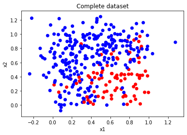

```python
# Nothing to do here

from sklearn.utils import shuffle
# Read data, split into X(features) and y(labels)
Z = np.genfromtxt('DataSetLR.csv', delimiter=',',skip_header=1)
X, y = Z[:,:-1], Z[:,-1]
y[:] = [0 if x==-1 else x for x in y]
# Plot data distribution
color= ['red' if elem==1 else 'blue' for elem in y ]
plt.scatter(X[:,0], X[:,1], c=color,label='the data')
plt.xlabel('x1')
plt.ylabel('x2')
plt.title('Complete dataset')
# Split into test and training set
X_train=X[:np.int(X.shape[0]/2)]
X_test=X[np.int(X.shape[0]/2):]
y_train=y[:np.int(len(y)/2)]
y_test=y[np.int(len(y)/2):]
```

```python
# If you use variable names pred_train and pred_test for the corrsponding predictions on training and test sets, then you can use the plotting routine below

#################################################
# Begin your code
w_train = fitLogRegModel(X_train, y_train)
pred_train = predictLogReg(w_train, X_train)
pred_test = predictLogReg(w_train, X_test)
# End your code
#################################################
```

```
iter = 0 loss = 125.33353013798353
iter = 1000 loss = 101.95282491822944
iter = 2000 loss = 93.92751018919574
iter = 3000 loss = 89.25130817205213
iter = 4000 loss = 86.31598387409389
iter = 5000 loss = 84.37474687844275
iter = 6000 loss = 83.0385020524325
iter = 7000 loss = 82.08965454878391
iter = 8000 loss = 81.3991473053722
iter = 9000 loss = 80.88664004961979
iter = 10000 loss = 80.50008552497948
iter = 11000 loss = 80.20463205968538
iter = 12000 loss = 79.97628760987608
iter = 13000 loss = 79.79814553322578
iter = 14000 loss = 79.6580527715864
Final loss =  79.55278552794275  iterations =   14943
```

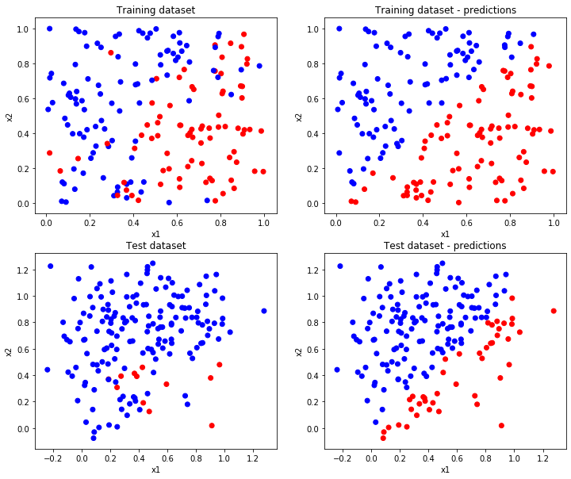

```python
# Nothing to do here
# Plot training and test dataset
# Plot predictions for training and test dataset

fig = plt.figure()
fig = plt.figure(figsize = (12,10))
plt.subplot(2, 2, 1)
color= ['red' if elem>0.5 else 'blue' for elem in y_train ]
plt.scatter(X_train[:,0], X_train[:,1], c=color,label='the data')
plt.xlabel('x1')
plt.ylabel('x2')
plt.title('Training dataset');

plt.subplot(2, 2, 2)
color= ['red' if elem>0.5 else 'blue' for elem in pred_train ]
plt.scatter(X_train[:,0], X_train[:,1], c=color,label='the data')
plt.xlabel('x1')
plt.ylabel('x2')
plt.title('Training dataset - predictions');

plt.subplot(2, 2, 3)
color= ['red' if elem>0.5 else 'blue' for elem in y_test ]
plt.scatter(X_test[:,0], X_test[:,1], c=color,label='the data')
plt.xlabel('x1')
plt.ylabel('x2')
plt.title('Test dataset');

plt.subplot(2, 2, 4)
color= ['red' if elem>0.5 else 'blue' for elem in pred_test ]
plt.scatter(X_test[:,0], X_test[:,1], c=color,label='the data')
plt.xlabel('x1')
plt.ylabel('x2')
plt.title('Test dataset - predictions');
```

```python
# Calculate accuracy and balanced accuracy for training set

#################################################
# Begin your code
from sklearn.metrics import accuracy_score, balanced_accuracy_score

y_pred_train = np.rint(pred_train)
score_train = accuracy_score(y_train, y_pred_train)
balanced_score_train = balanced_accuracy_score(y_train, y_pred_train)
print('Accuracy for training set = ', score_train, 'and Balanced Accuracy = ', balanced_score_train)

# End your code
#################################################
```

```
Accuracy for training set =  0.7942857142857143 and Balanced Accuracy =  0.7981099656357389
```

```python
# Calculate accuracy and balanced accuracy for test set

#################################################
# Begin your code
from sklearn.metrics import accuracy_score, balanced_accuracy_score

y_pred_test = np.rint(pred_test)
score_test = accuracy_score(y_test, y_pred_test)
balanced_score_test = balanced_accuracy_score(y_test, y_pred_test)
print('Accuracy for test set = ', score_test, 'and Balanced Accuracy = ', balanced_score_test)


# End your code
#################################################
```

```
Accuracy for test set =  0.7542857142857143 and Balanced Accuracy =  0.6365030674846626
```

```
Area Under the Curve (AUC) = 0.85
```

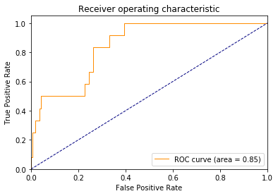

```python
# ROC curve

#################################################
# Begin your code

from sklearn.metrics import roc_curve, auc
# Compute ROC curve and ROC area for each class
fpr, tpr, thresholds = roc_curve(y_test, pred_test)
roc_auc = auc(fpr, tpr)
print('Area Under the Curve (AUC) = %0.2f' % roc_auc)

plt.figure()
lw = 1
plt.plot(fpr, tpr, color='darkorange',
         lw=lw, label='ROC curve (area = %0.2f)' % roc_auc)
plt.plot([0, 1], [0, 1], color='navy', lw=lw, linestyle='--')
plt.xlim([0.0, 1.0])
plt.ylim([0.0, 1.05])
plt.xlabel('False Positive Rate')
plt.ylabel('True Positive Rate')
plt.title('Receiver operating characteristic')
plt.legend(loc="lower right")
plt.show()


# End your code
#################################################
```

### Question (10 points)

Also use learning rates $\eta = 10^{-1}$, $\eta = 10^{-6}$, and $\eta = 10^{-8}$ and compare the results (iterations needed, accuracies, area under ROC curve) to the case of $\eta = 10^{-4}$. Comment on your observations.

for $\eta = 10^{-1}$

- required iterations = 14
- Accuracy for training set = 0.7942857142857143 and Balanced Accuracy = 0.7955987311657415
- Accuracy for test set = 0.7657142857142857 and Balanced Accuracy = 0.6426380368098159
- Area Under the Curve (AUC) = 0.85

for $\eta = 10^{-6}$

- Required iterations = 99999
- Accuracy for training set = 0.7657142857142857 and Balanced Accuracy = 0.7635474491144594
- Accuracy for test set = 0.7714285714285715 and Balanced Accuracy = 0.6457055214723926
- Area Under the Curve (AUC) = 0.86

for $\eta = 10^{-8}$

- Required iterations = 99999
- Accuracy for training set = 0.44571428571428573 and Balanced Accuracy = 0.496233148295004
- Accuracy for test set = 0.08571428571428572 and Balanced Accuracy = 0.47060327198364005
- Area Under the Curve (AUC) = 0.12

Therefore, small learning rate increase the number of iteration but it doesn't improve the accuracy and AUC considerably. Too small rate may be reduce the accuracy of the method.